# Assignment on Data Science for Good: Center for Policing Equity

Name: YASWANTH MARAM, Mail: ym20741@essex.ac.uk

February 19th, 2021

### Introduction:

We are given data which has Crime Incident cases happened in Dallas, USA. The data consist of 2384 incidences with available information on 47 variables providing us information on the incidents, dates, officers, subjects, locations, race, time, and other metrics. We will investigate the data by providing descriptive statistics for all relevant variables and formulate some interesting questions and try to answer them by doing exploratory data analysis.

#### Interesting Questions:

1. How is the spread of incidents across year, months, hours? Is there any trend?
2. Study of incident/crime rates across different subject Races?
3. Is there any disparity between races in Officers and Subjects?
4. Is the crime rate increasing or decreasing among division?
5. Are there any specific reasons for arrests?
6. Is it more likely for an officer with a few years in the force to use violence?

### Exploratory Analysis:

#### 1.Spread of incidents across year, months, hours:

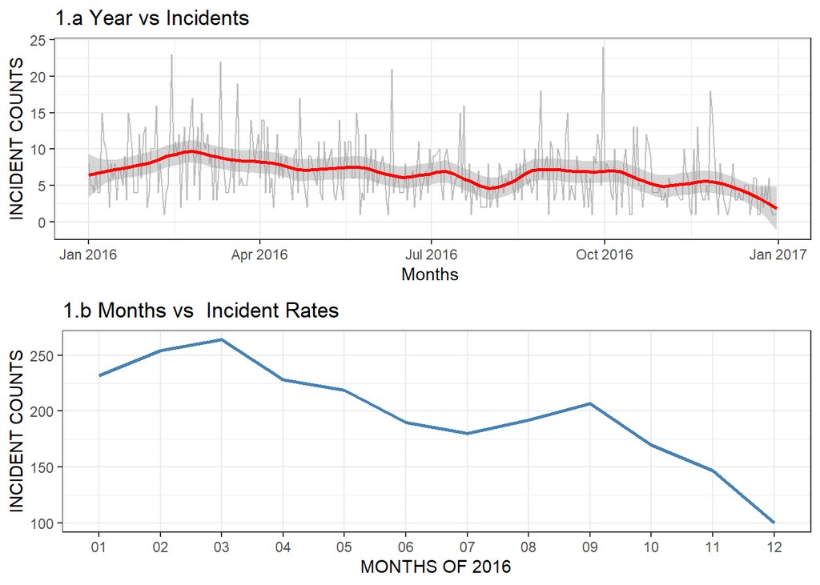

- From figure 1.a and 1.b it is very clear that the incidents have been gradually reducing in the year 2016.
- March has the highest number of incidents, while December has the least number. This may be the result of due to seasonality (holidays).

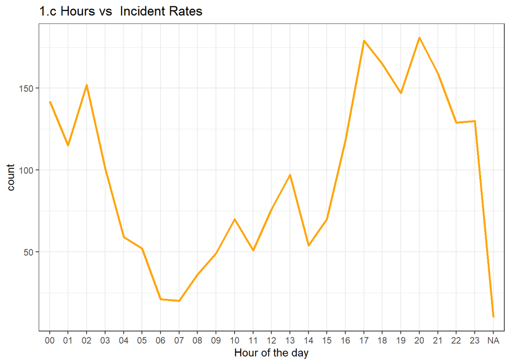

- From figure 1.c we can clearly see that the number of incidents reported were lowest at 6a.m & 7a.m and highest at 5p.m & 8p.m

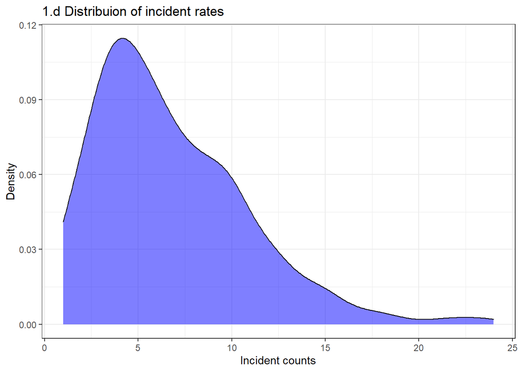

- From figure 1.d we can clearly see right skewness in the incident count.

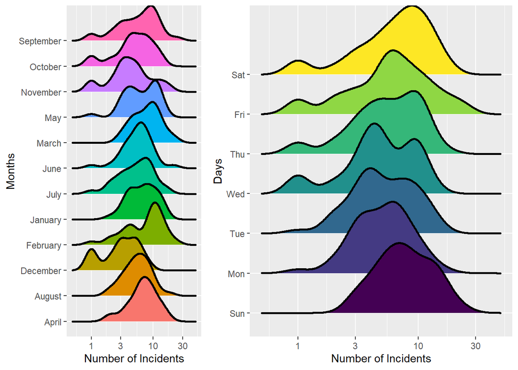

- The above figures show the number of Incidences plotted against Months and days. We can see skewness in the months of September, December, February, May and October.
- The mean range of incidents is between 3 to 10 for both days and months.

#### 2. Study of Incident rates for Subject Races:

Boxplot analysis will give us more intuition about the quartile ranges, medians and outliers.

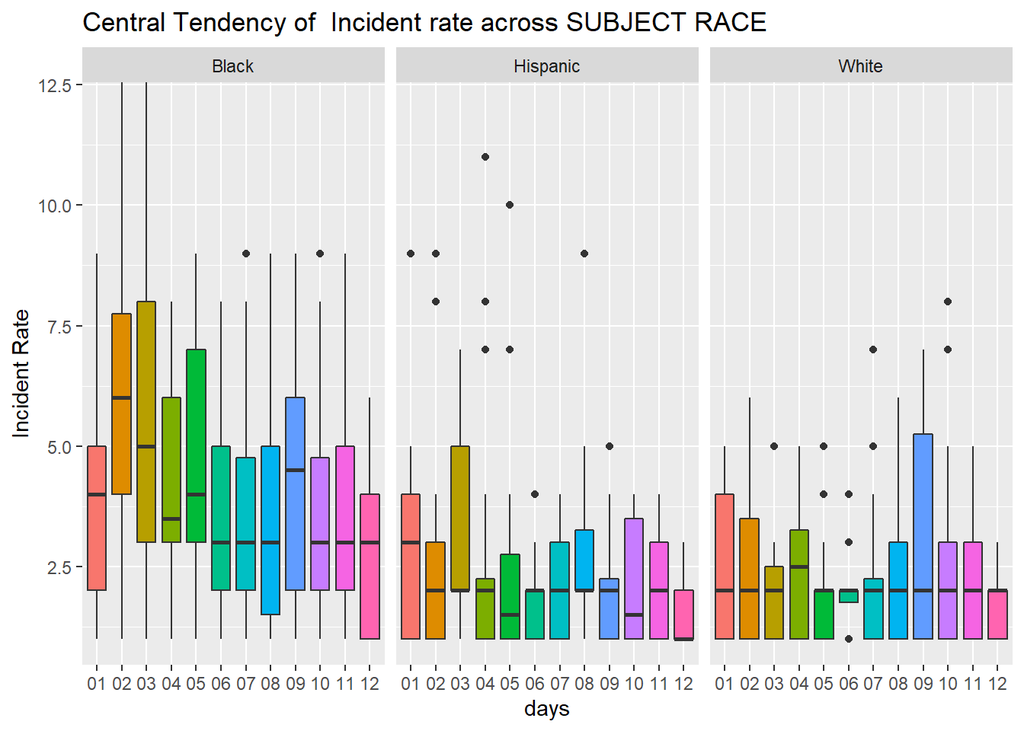

- From the graphs above it is evident that the black people have more incident rates compared to Hispanic and whites.
- More outliers are observed with Hispanic and white population than blacks.

#### 3. Officers vs Subjects Races Analysis:

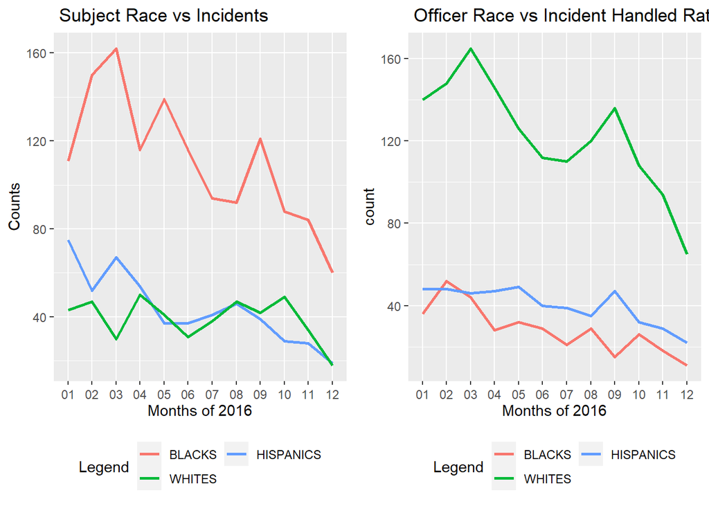

In the above graph we can clearly see that the number of black and Hispanic officers handling the incidents is very less compared to white officers while for subjects it is quite opposite.

#### 4. Division analysis:

In the below figure the 7 divisions have been plotted against the months in x-axis and incident counts in y-axis.

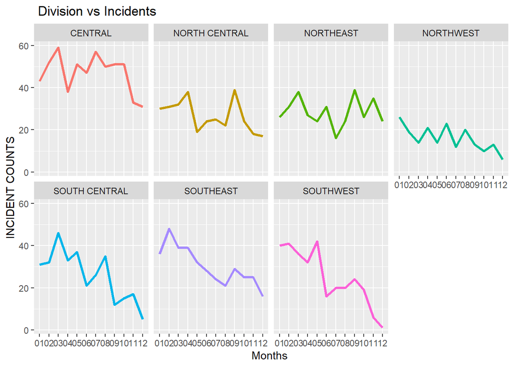

We can clearly see that the central division has the greatest number of crimes reported. A neutral trend has been observed from northeast and north central divisions. Steep slopes are observed for northwest, south central, southeast, and southwest divisions.

#### 5. Reasons for Arrest distributions:

In the below graph we can observe the distributions of rates of various subject descriptions i.e. reasons for arrests across the year.

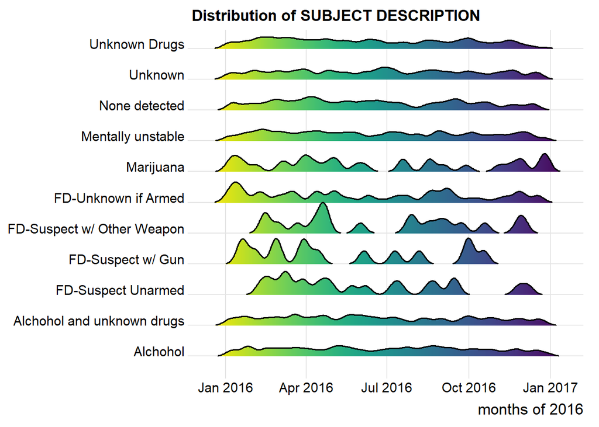

We can clearly see that the Mentally ill, narcotics and alcohol incident rates have been neutral over the year, while gun offenders have recurring peaks in incident rates.

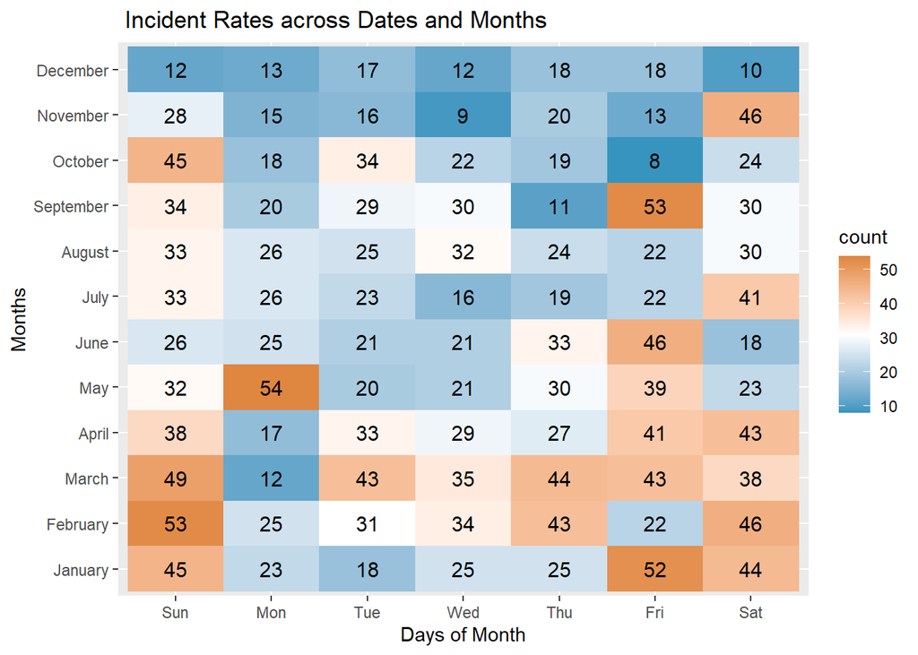

We can clearly see that the incident rates are more during weekends rather than weekdays from the above graph.

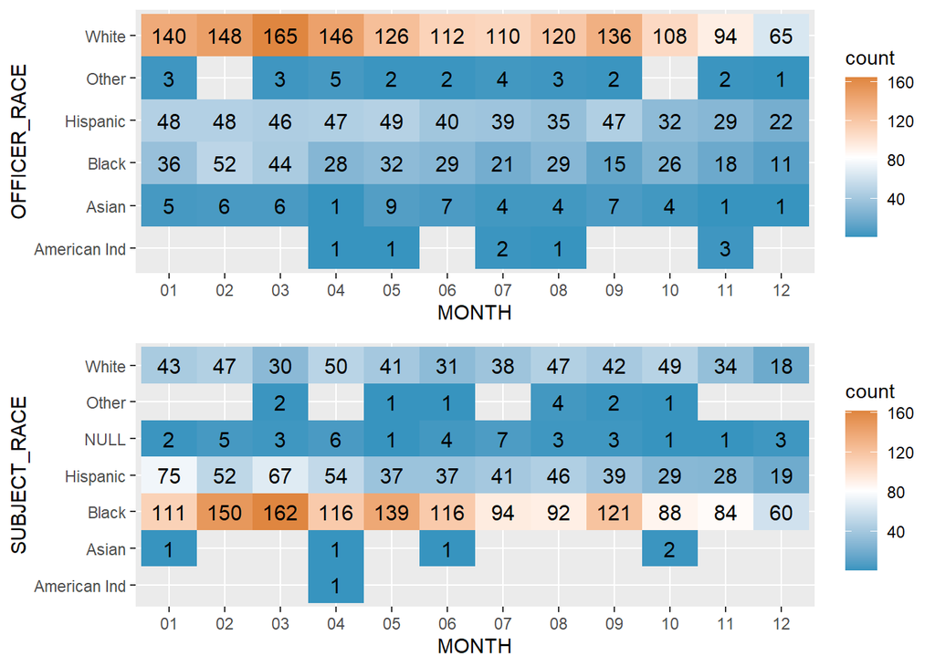

#### 6. Officer experience analysis:

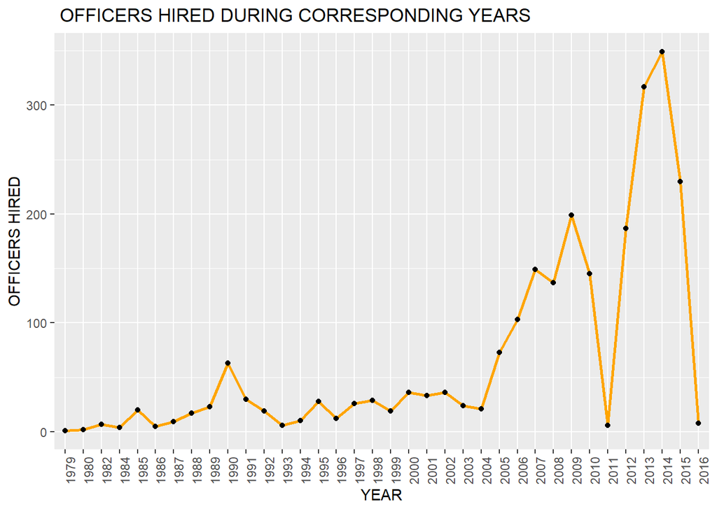

We can clearly see a high number of officers hired in the years 2012 to 2015.

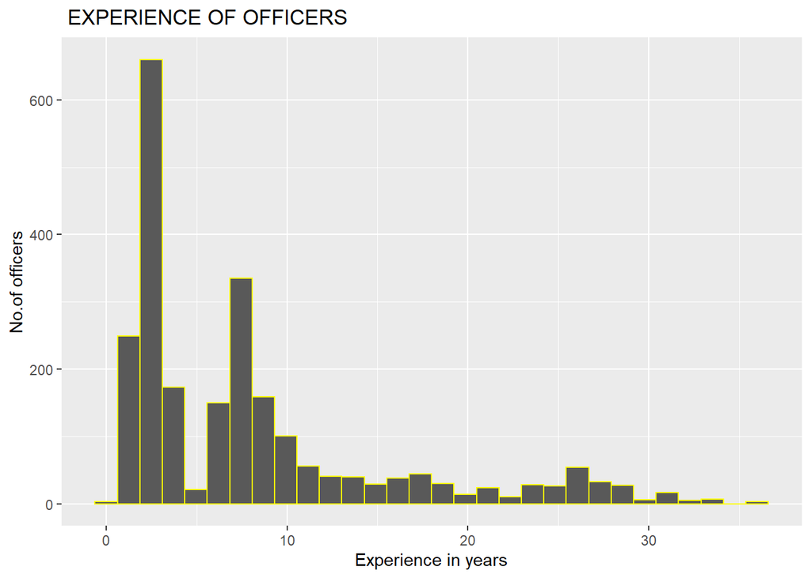

We can see majority number of officers have fewer than 10 years of experience.

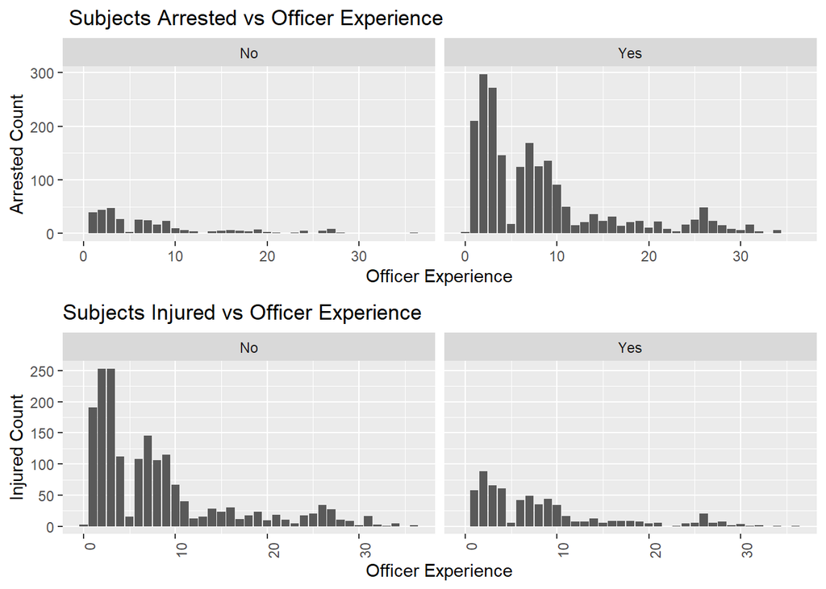

The above figure clearly shows that officers with fewer than 10 years experience have arrested more subjects without any injury on the field.

### References:

1.https://moodle.essex.ac.uk/

2.https://www.kaggle.com/